# Notebook Structure

# 4. How to Interpret Density plot :

Key Features to Look For

Shape:

- Symmetric: The left and right sides of the curve are roughly mirror images.
- Skewed: The curve has a "tail" extending more to one side.
  - Right-skewed (positive skew): The tail extends to the right.
  - Left-skewed (negative skew): The tail extends to the left.
- Unimodal: The curve has one peak.
- Bimodal: The curve has two peaks.
- Multimodal: The curve has more than two peaks.

Center: Where is the data concentrated? Look for the peak of the curve, which gives you an idea of the typical value (similar to the mode in a histogram).

Spread: How much does the data vary?

- Narrow curve: Data points are clustered close together.
- Wide curve: Data points are more spread out.

Outliers: Density plots don't show outliers as explicitly as histograms, but outliers can influence the shape of the tail of the curve. A long tail in one direction might suggest the presence of outliers.

Gaps: Density plots, by their nature, create a continuous curve, so they don't show gaps in the same way histograms do. However, very low-density regions might hint at a sparsity of data in those intervals.

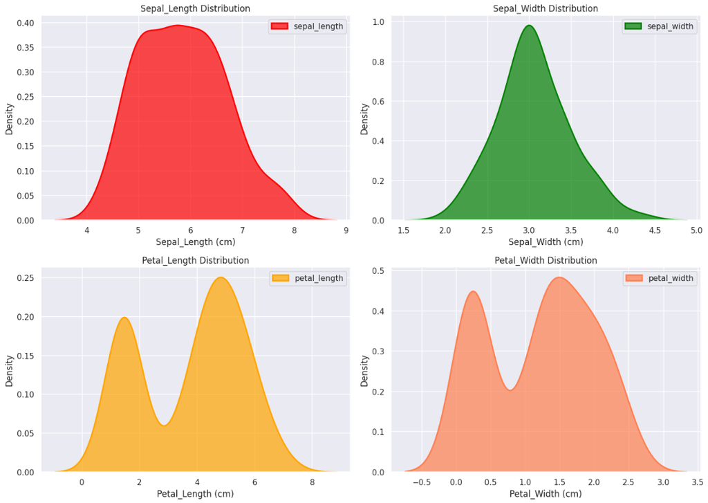